# Introduction to R

R Markdown demo

Clémentine Cottineau

Claudiu Forgaci

05 December 2021

## Introduction

This document is meant to demonstrate the practical use of R for automation, statistics, visualisation and reproducibility in an *R Markdown document*. We show basic examples of data collection through a computation loop, visualisation of non-spatial and spatial data, and interpretation.

We start by loading the packages that will be used in this notebook.

```r
library(tidyverse)  # collection of packages for data manipulation, visualisation, etc.
#library(googlesheets4)  # access data from Google sheets
library(sf)  # working with spatial data
library(osmdata)  # access OpenStreetMap data via the Overpass API
library(osmextract)  # retrieve bulk OpenStreetMap data
library(ggmap)
library(kableExtra)  # create and style HTML tables
```

## Reading the data

One way to get the survey data would be to read it from several `csv` files, for instance information received from students in a course, or from participants in a research project.

```r
# lists the files with "survey-" in their name in the same folder as this document
files <- list.files(pattern="^survey-")
files
```

```
## [1] "survey-dummy1.csv" "survey-dummy2.csv" "survey-dummy3.csv"
```

For this, we will use a ‘for-loop’, i.e. a simple recursive function very useful to automate operations.

```r
# creates an empty table
survey <- tibble()
i=1
n <- length(files)
# the 'for-loop':
for (i in 1:n){
  f <- read.csv2(files[i], header=F)
  if(i == 1){
    survey <- f
  } else {
    survey <- cbind(survey, f[,2])
  }
}

transpose <- as.data.frame(t(survey))
colnames(transpose) <- c("Name", "ArrivalYearTU", "CityBefore", "InterestR", "Experience")
survey_together <- transpose[-1,]
rownames(survey_together) <- 1:n
 survey_together$ArrivalYearTU <- as.numeric(survey_together$ArrivalYearTU)
 survey_together$InterestR <- as.numeric(survey_together$InterestR)

 # as with spreadsheets, we can create new variables
 survey_together$SeniorityAtTUD <- 2021 - survey_together$ArrivalYearTU
survey_together
```

```
##     Name ArrivalYearTU    CityBefore InterestR Experience SeniorityAtTUD
## 1 Sjoerd          2014      Delft NL         2          N              7
## 2 Marina          2019     Bucharest         5          Y              2
## 3 Damien          2020 Paris, France         4          N              1
```

It still goes quicker to do it by hand for 3 files, but when the number of files increases (or when files change), the code is the same, and this is when it makes sense to automate the process.

## Visualising non-spatial data: Making graphs

Let’s visualise some non spatial data, for instance the relation between the semiority at TU Delft and the reported interest in R.

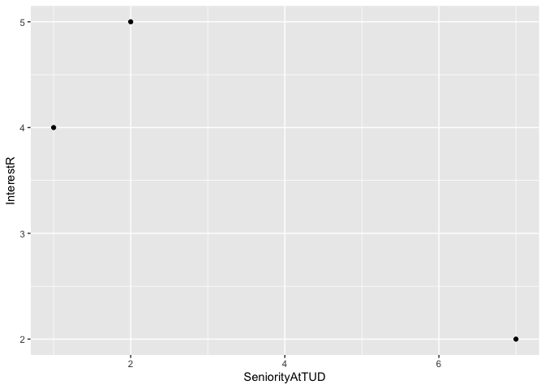

```r
library(ggplot2)

q <- ggplot(survey_together, aes(x=SeniorityAtTUD, y=InterestR))
q+ geom_point()
```

We can even estimate a linear regression between the two and visualise the result.

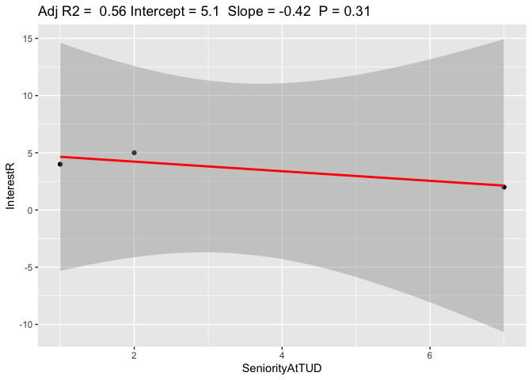

```r
fit <- lm(InterestR ~ SeniorityAtTUD, data = survey_together)

ggplot(fit$model, aes_string(x = names(fit$model)[2], y = names(fit$model)[1])) +
  geom_point() +
  stat_smooth(method = "lm", col = "red") +
  labs(title = paste("Adj R2 = ",round(signif(summary(fit)$adj.r.squared, 2), digits = 3),
                     "Intercept =",signif(fit$coef[[1]],2 ),
                     " Slope =",signif(fit$coef[[2]], 2),
                     " P =",signif(summary(fit)$coef[2,4], 2)), cex=2)
```

## Visualising spatial data: Making maps

```r
library(sf)
library(osmextract)
library(osmdata)
library(leaflet)

# get places from csv survey
places <- survey_together[, "CityBefore"]

for (i in 1:n){
## get municipal boundary from osmdata
bb <- osmdata::getbb(
            place_name = places[i],
            format_out = 'sf_polygon',
            silent = FALSE
        )
  assign(paste0("bb", i), bb)
  if(i == 1){
    bbx <- bb
  } else{
    bbx <- rbind(bbx, bb)
  }
}
```

```
## [1] "https://nominatim.openstreetmap.org/?q=Delft%20NL&featuretype=settlement&polygon_text=1&format=json&limit=10"
## [1] "https://nominatim.openstreetmap.org/?q=Bucharest&featuretype=settlement&polygon_text=1&format=json&limit=10"
## [1] "https://nominatim.openstreetmap.org/?q=Paris%2C%20France&featuretype=settlement&polygon_text=1&format=json&limit=10"
```

```r
#map places on interactive map
    leaflet(bbx) %>% addProviderTiles("CartoDB.Positron") %>%
      addPolygons()
```

[interactive chart not shown]

Let’s extract streets from a city

```
## [1] "https://nominatim.openstreetmap.org/?q=Rotterdam&featuretype=settlement&polygon_text=1&format=json&limit=10"
```

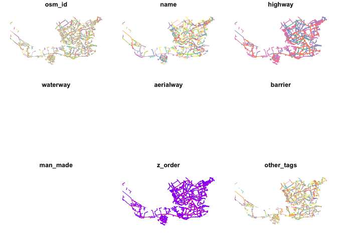

```r
## create a function to extract the streets of a city x
map_city_streets <- function(x){
osm_lines = oe_get(x, stringsAsFactors = FALSE, quiet = TRUE)
nrow(osm_lines)
ht <- c("primary", "secondary", "tertiary", "unclassified") # highway types of interest
bb <- osmdata::getbb(
            place_name = x,
            format_out = 'sf_polygon',
            silent = FALSE
        )
osm_major_roads_place <- osm_lines[osm_lines$highway %in% ht, ] %>%
    sf::st_intersection(bb)

plot(osm_major_roads_place)

    }


## let's map it for Rotterdam
map_city_streets("Rotterdam")
```

Let’s try with the last respondent’s response

```
## [1] "https://nominatim.openstreetmap.org/?q=Paris%2C%20France&featuretype=settlement&polygon_text=1&format=json&limit=10"
```

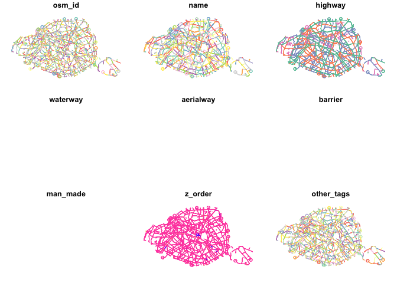

```r
map_city_streets(places[n])
```